# TNTP cookbook for R graphics

Last updated: 2023-08-15

## How to create TNTP style graphics

At the TNTP data team, we have developed an R package and an R cookbook to make the process of creating publication-ready graphics in our in-house style using R’s ggplot2 library a more reproducible process, as well as making it easier for people new to R to create graphics.

We’ll get to how you can put together the various elements of these graphics, but **let’s get the admin out of the way first…**

### Load all the libraries you need

A few of the steps in this cookbook - and to create charts in R in general - require certain packages to be installed and loaded. So that you do not have to install and load them one by one, you can use the `p_load` function in the `pacman` package to load them all at once with the following code.

```r
#This line of code installs the pacman page if you do not have it installed - if you do, it simply loads the package
if(!require(pacman))install.packages("pacman")

pacman::p_load('tidyverse')
```

### Install the tntpr package

`tntpr` is not on CRAN, so you will have to install it directly from Github using `devtools`.

If you do not have the `devtools` package installed, you will have to run the first line in the code below as well.

```r
# install.packages('devtools')
devtools::install_github('tntp/tntpr')
```

For more info on `tntpr` check out the [package’s Github repo](https://github.com/tntp/tntpr), but most of the details about how to use the package and its functions are detailed below.

When you have downloaded the package and successfully installed it you are good to go and create charts.

### How does the tntpr package work?

The package has two functions, `tntp_style()` and `finalise_plot()`.

`tntp_style()`: has no arguments and is added to the ggplot ‘chain’ after you have created a plot. What it does is generally makes text size, font and color, axis lines, axis text, margins and many other standard chart components into TNTP style, which has been formulated based on recommendations and feedback from the design team.

`tntp_style()` uses the ‘Segoe UI’ font because this font is TNTP’s base font. You must load the font into R. This process is beyond the scope of this tutorial, but the [`extrafont` package](https://github.com/wch/extrafont) can be used to load the font into R.

Note that colors for lines in the case of a line chart or bars for a bar chart, do not come out of the box from the `tntp_style()` function, but need to be explicitly set in your other standard `ggplot` chart functions.

The code below shows how the `tntp_style()` should be used within standard chart-production workflow. This is an example for a very simple line chart. It uses the fake data set `fake_county` from the `tntpr` package and plots the average salary each year.

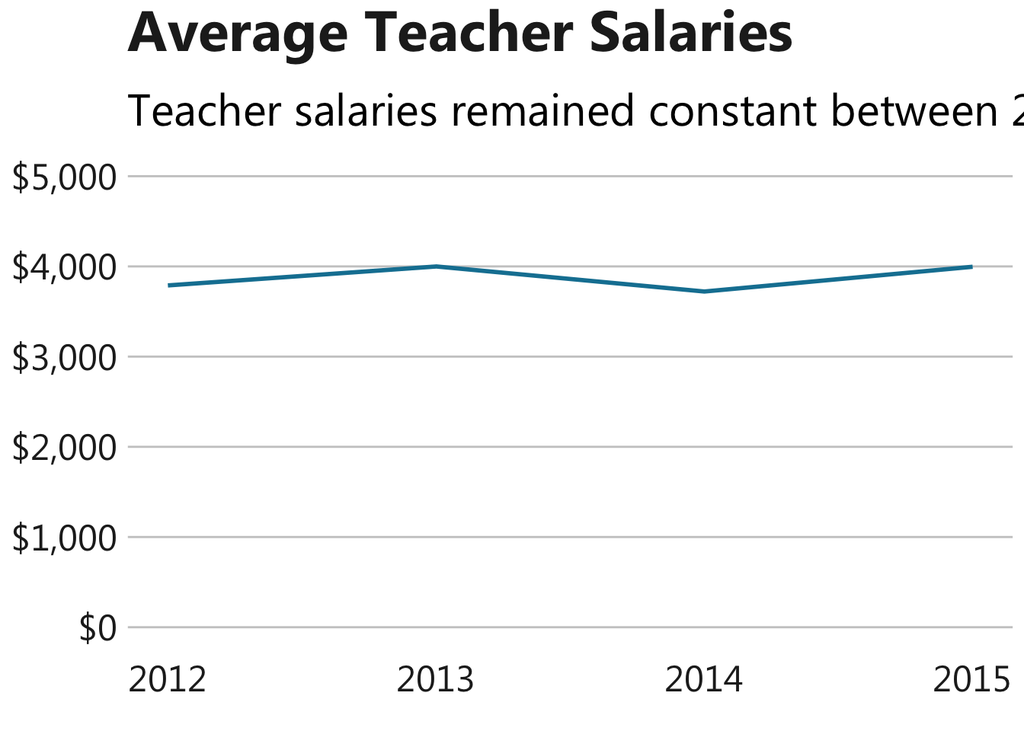

```r
# load fake data into global environment
# remove all salaries of 0
county_data <- tntpr::fake_county |>
  filter(t_salary > 0)

avg_salary <- county_data |>
  filter(t_salary != 0) |>
  group_by(school_year) |>
  summarize(avg_salary = mean(t_salary, na.rm = TRUE), .groups = "drop")

#Make plot
avg_salary_line_plot <- ggplot(avg_salary, aes(x = school_year, y = avg_salary)) +
  geom_line(colour = "#1380A1", size = 1) +
  scale_y_continuous(labels = scales::dollar, limits = c(0, 5000)) +
  tntp_style() +
  labs(
    title="Average Teacher Salaries",
    subtitle = "Teacher salaries remained constant between 2012 and 2015",
    x = NULL,
    y = 'Average teacher salary'
  )

avg_salary_line_plot
```

Here is what the `tntp_style()` function actually does under the hood. It essentially modifies certain arguments in the `theme` function of `ggplot2`.

For example, the first argument is setting the font, size, typeface and color of the title element of the plot.

```
## function ()
## {
##     font <- "Segoe UI"
##     ggplot2::theme(plot.title = ggplot2::element_text(family = font,
##         size = 28, face = "bold", color = "#222222"), plot.subtitle = ggplot2::element_text(family = font,
##         size = 22, margin = ggplot2::margin(9, 0, 9, 0)), plot.caption = ggplot2::element_blank(),
##         legend.position = "top", legend.text.align = 0, legend.background = ggplot2::element_blank(),
##         legend.title = ggplot2::element_blank(), legend.key = ggplot2::element_blank(),
##         legend.text = ggplot2::element_text(family = font, size = 18,
##             color = "#222222"), axis.title = ggplot2::element_blank(),
##         axis.text = ggplot2::element_text(family = font, size = 18,
##             color = "#222222"), axis.text.x = ggplot2::element_text(margin = ggplot2::margin(5,
##             b = 10)), axis.ticks = ggplot2::element_blank(),
##         axis.line = ggplot2::element_blank(), panel.grid.minor = ggplot2::element_blank(),
##         panel.grid.major.y = ggplot2::element_line(color = "#cbcbcb"),
##         panel.grid.major.x = ggplot2::element_blank(), panel.background = ggplot2::element_blank(),
##         strip.background = ggplot2::element_rect(fill = "white"),
##         strip.text = ggplot2::element_text(size = 22, hjust = 0))
## }
## <bytecode: 0x1415627b0>
## <environment: namespace:tntpr>
```

You can modify these settings for your chart, or add additional theme arguments, by calling the `theme` function with the arguments you want - but please note that for it to work you must call it *after* you have called the `tntp_style` function. Otherwise `tntp_style()` will override it.

This will add some gridlines, by adding extra theme arguments to what is included in the `tntp_style()` function. There are many similar examples throughout the cookbook.

```r
theme(panel.grid.major.x = element_line(color="#cbcbcb"),
      panel.grid.major.y=element_blank())
```

### Save out your finished chart

After adding the `tntp_style()` to your chart there is one more step to get your plot ready for publication. `finalise_plot()` will left-align the title, subtitle and add the footer with a source and an image in the bottom right corner of your plot. It will also save it to your specified location. The function has six arguments:

Here are the function arguments: `finalise_plot(plot_name, source, save_filepath, width_pixels = 640, height_pixels = 450)`

- `plot_name`: the variable name that you have called your plot, for example for the chart example above `plot_name` would be `"line"`
- `source`: the source text that you want to appear at the bottom left corner of your plot. You will need to type the word `"Source:"` before it, so for example `source = "Source: ONS"` would be the right way to do that.
- `save_filepath`: the precise filepath that you want your graphic to save to, including the `.png` extension at the end. This does depend on your working directory and if you are in a specific R project. An example filepath would be: `Desktop/R_projects/charts/line_chart.png`.
- `width_pixels`: this is set to 640px by default, so only call this argument if you want the chart to have a different width, and specify what you want it to be.
- `height_pixels`: this is set to 450px by default, so only call this argument if you want the chart to have a different height, and specify what you want it to be.
- `logo_image_path`: this argument specifies the path for the image/logo in the bottom right corner of the plot. The default is for a placeholder PNG file with a background that matches the background colour of the plot, so do not specify the argument if you want it to appear without a logo. If you want to add your own logo, just specify the path to your PNG file. The package has been prepared with a wide and thin image in mind.

Example of how the `finalise_plot()` is used in a standard workflow. This function is called once you have created and finalized your chart data, titles and added the `tntp_style()` to it:

```r
finalise_plot(
  plot_name = avg_salary_line_plot,
  source = "Example District Data",
  save_filepath = "avg_slaries_plot.png",
  width_pixels = 640,
  height_pixels = 450
  # we are not setting a placeholder image, so `logo_image_path` will default to a clear logo
)
```

So once you have created your plot and are relatively happy with it, you can use the `finalise_plot()` function to make the final adjustments and save out your chart so that you can look at it outside RStudio.

It is important to mention that it is a good idea to do this early on because the position of the text and other elements do not render accurately in the RStudio Plots panel because this depends on the size and aspect ratio you want your plot to appear, so saving it out and opening up the files give you an accurate representation of how the graphic looks.

The finalise_plot() function does more than just save out your chart, it also left-aligns the title and subtitle as is standard for TNTP graphics, adds a footer with the logo on the right side and lets you input source text on the left side.

## Make a line chart

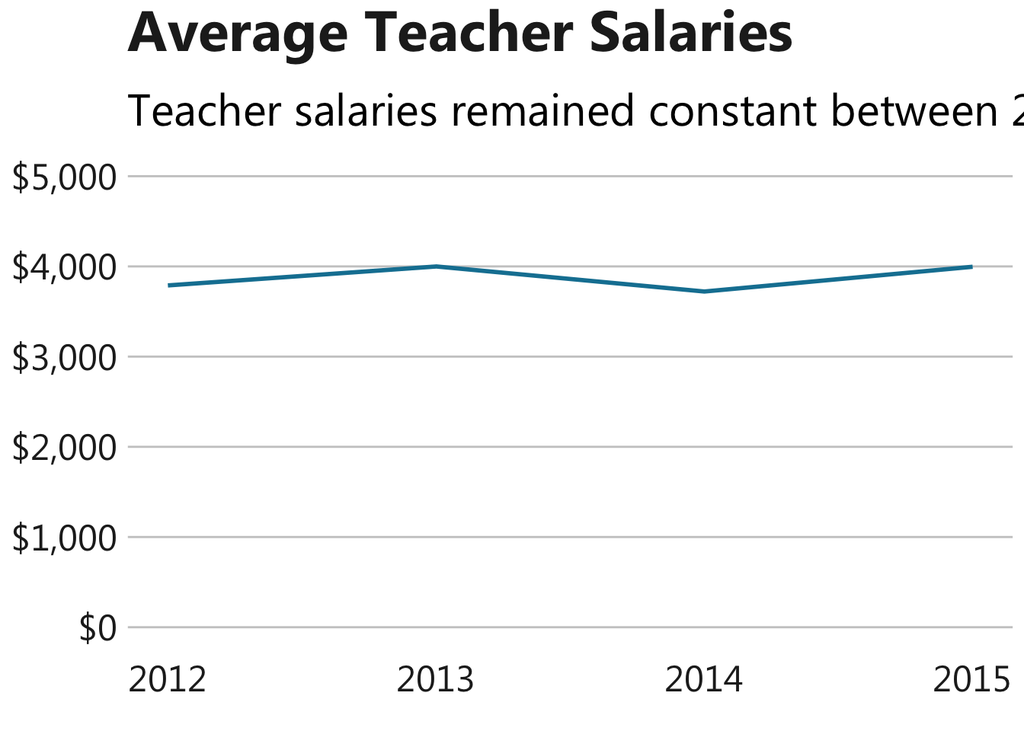

```r
#Make plot
line <- ggplot(avg_salary, aes(x = school_year, y = avg_salary)) +
  geom_line(colour = "#1380A1", size = 1) +
  scale_y_continuous(labels = scales::dollar, limits = c(0, 5000)) +
  tntp_style() +
  labs(
    title="Average Teacher Salaries",
    subtitle = "Teacher salaries remained constant between 2012 and 2015",
    x = NULL,
    y = 'Average teacher salary'
  )
```

## Make a multiple line chart

Note that in the multiple line chart, we overwrote `ggplot2`’s default color scheme to incorporate TNTP colors. We pulled the hex codes for the colors we wanted to use with `line_colors <- as.character(tntpr::colors_tntp[c('medium_blue', 'gold_3')])` and then added the custom colors with `scale_colour_manual(values = line_colors)`.

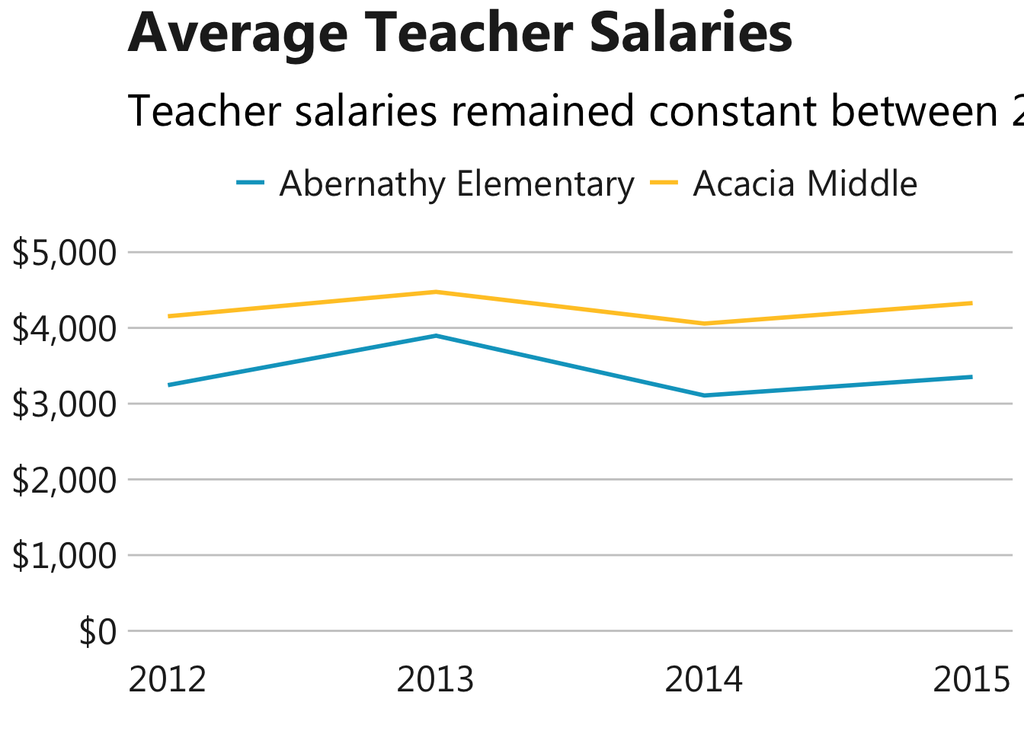

```r
#Prepare data
school_salary <- county_data |>
  filter(t_salary != 0) |>
  group_by(school_year, school_name) |>
  summarize(avg_salary = mean(t_salary, na.rm = TRUE), .groups = "drop")

# create list of school names so we can easily filter data set for the number of schools we want
school_names <- unique(school_salary$school_name)

# only plot two schools
line_plot_schools <- school_salary |>
  filter(school_name %in% school_names[1:2])

line_colors <- as.character(tntpr::colors_tntp[c('medium_blue', 'gold_3')])

#Make plot
multiple_line <- ggplot(line_plot_schools, aes(x = school_year, y = avg_salary, color = school_name)) +
  geom_line(size = 1) +
  scale_y_continuous(labels = scales::dollar, limits = c(0, 5000)) +
  scale_colour_manual(values = line_colors) +
  tntp_style() +
  labs(
    title="Average Teacher Salaries",
    subtitle = "Teacher salaries remained constant between 2012 and 2015",
    x = NULL,
    y = 'Average teacher salary'
  )
```

## Make a bar chart

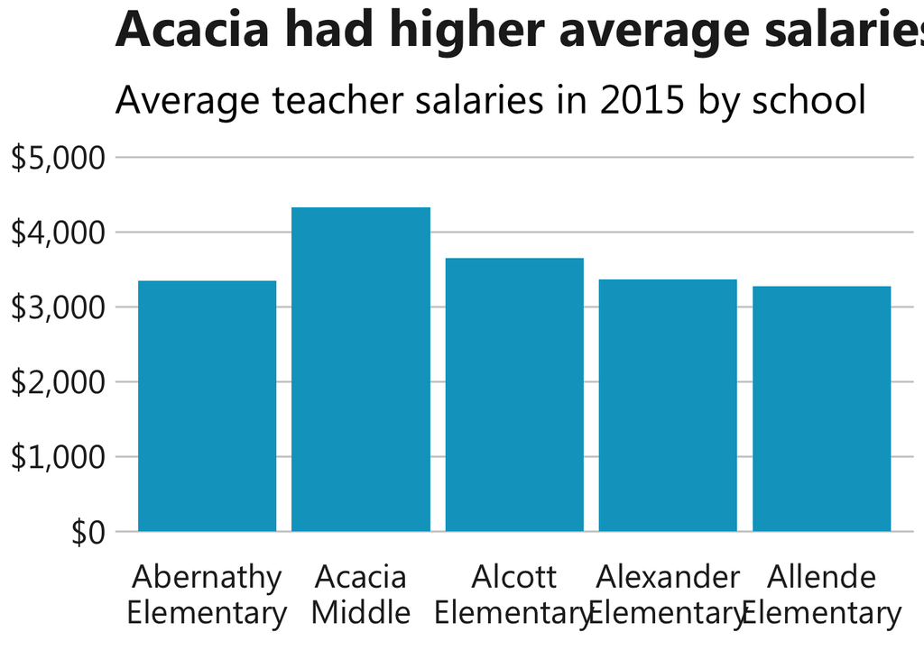

```r
#Prepare data
bar_df <- school_salary |>
  filter(
    school_year == 2015,
    school_name %in% school_names[1:5]
  ) |>
  # add line breaks for better plotting
  mutate(school_name = str_wrap(school_name, 7))

#Make plot
bars <- ggplot(bar_df, aes(x = school_name, y = avg_salary)) +
  geom_bar(stat="identity",
           position="identity",
           fill= tntpr::colors_tntp[['medium_blue']]) +
  scale_y_continuous(labels = scales::dollar, limits = c(0, 5000)) +
  tntp_style() +
  labs(
    title="Acacia had higher average salaries in 2015",
    subtitle = "Average teacher salaries in 2015 by school"
  )
```

## Make a stacked bar chart

The stacked bar chart uses percentages on the y-axis. Note the formatting of the y-axis to create the percentages: `scale_y_continuous(labels = scales::percent, limits = c(0,1))`. We set `limits = c(0,1)` to ensure the y-axis limits run from 0% to 100%. When working with percentages, the axis should (almost) always run from 0% to 100%. Additionally, in `geom_bar()` we set `stat = "identity"`. This tells `ggplot2` to plot the data as-is and to not aggregate the data when making the plot. It is often easier to aggregate data outside of `ggplot2`, more transparent, and easier to check. We could have also replaced `geom_bar(stat = "identity", position = "stack")` with `geom_col()` (no parameters needed) to arrive at the same plot.

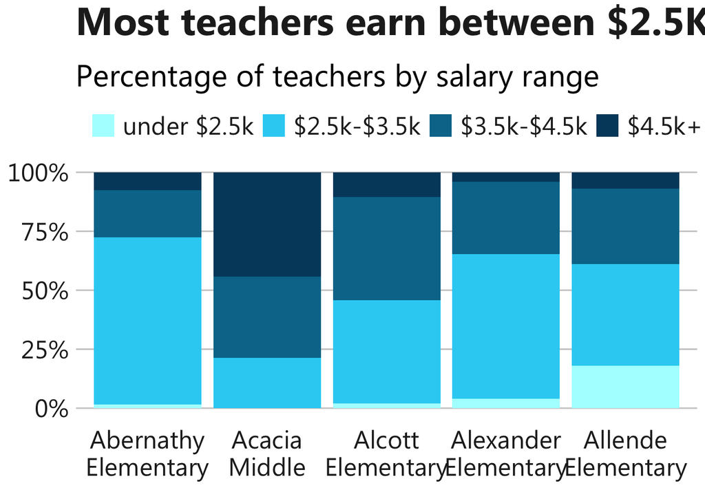

```r
#prepare data
stacked_df <- county_data |>
  filter(
    school_year == 2015,
    school_name %in% school_names[1:5]
  ) |>
  mutate(t_salary_cut = cut(t_salary,
                    breaks = c(0, 2500, 3500, 4500, 10000),
                    labels = c("under $2.5k", "$2.5k-$3.5k", "$3.5k-$4.5k", "$4.5k+"))) |>
  group_by(school_name, t_salary_cut) |>
  summarise(n_cut_school = n(), .groups = "drop_last") |>
  mutate(
    n_cut_salary = sum(n_cut_school, na.rm = TRUE),
    perc_in_each_cut = n_cut_school / n_cut_salary
  )  |>
  # add line breaks for better plotting
  mutate(school_name = str_wrap(school_name, 7))

#set order of stacks by changing factor levels
stacked_df$t_salary_cut = factor(stacked_df$t_salary_cut, levels = rev(levels(stacked_df$t_salary_cut)))

colors_to_use <- rev(as.character(colors_tntp[c('blue_1', 'blue_2', 'blue_4', 'blue_5')]))

#create plot
stacked_bars <- ggplot(
  data = stacked_df,
  aes(x = school_name, y = perc_in_each_cut, fill = t_salary_cut)
) +
  geom_bar(stat = "identity", position = "stack") +
  tntp_style() +
  scale_y_continuous(labels = scales::percent, limits = c(0,1)) +
  scale_fill_manual(values = colors_to_use) +
  labs(title = "Most teachers earn between $2.5K and $4.5K",
       subtitle = "Percentage of teachers by salary range") +
  theme(legend.position = "top",
        legend.justification = "left") +
  guides(fill = guide_legend(reverse = TRUE))
```

This example shows proportions, but you might want to make a stacked bar chart showing number values instead - this is easy to change!

The value passed to the `position` argument will determine if your stacked chart shows proportions or actual values.

`position = "fill"` will draw your stacks as proportions, and `position = "identity"` will draw number values.

## Make a grouped bar chart

Making a grouped bar chart is very similar to making a bar chart. You just need to change `position = "identity"` to `position_dodge2(preserve = "single")`.

Note the use of the named vector `colors_to_use` to expressly map colors to values. This is a safe way to ensure we are properly mapping colors to values.

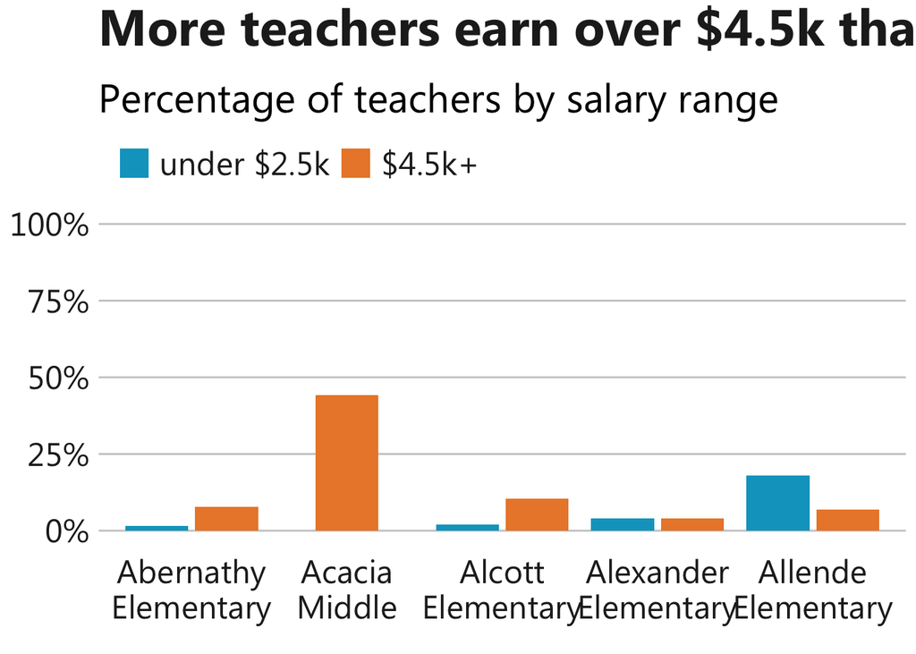

```r
# only plot the lowest and highest earning groups
earnings_to_keep <- levels(stacked_df$t_salary_cut)[c(4,1)]

# map bar colors to values
colors_to_use <- colors_tntp[c('medium_blue', 'orange_3')] |>
  set_names(earnings_to_keep)

dodged_df <- stacked_df |>
  # only plot the lowest and highest earning groups
  filter(t_salary_cut %in% !!earnings_to_keep) |>
  # switch order of factors so that the lowest earnings plot first
  mutate(t_salary_cut = factor(t_salary_cut, levels = earnings_to_keep))

ggplot(dodged_df, aes(x = school_name, y = perc_in_each_cut, fill = t_salary_cut)) +
    geom_bar(stat = "identity", position = position_dodge2(preserve = "single")) +
    tntp_style() +
    scale_y_continuous(labels = scales::percent, limits = c(0,1)) +
    scale_fill_manual(values = colors_to_use) +
    labs(title = "More teachers earn over $4.5k than under $2.5k",
         subtitle = "Percentage of teachers by salary range") +
    theme(legend.position = "top",
          legend.justification = "left")
```

## Make a dumbbell chart

Another way of showing difference is a dumbbell chart. Note that `geom_dumbell()` comes from the [`ggalt`](https://yonicd.github.io/ggalt/index.html) package.

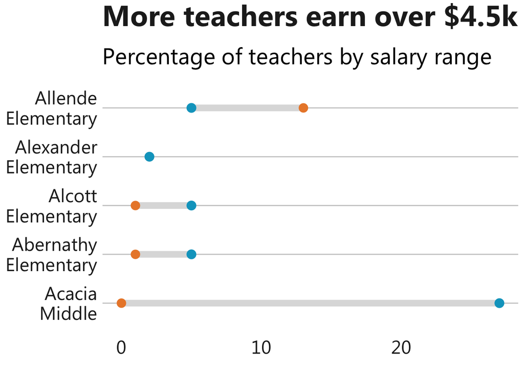

```r
dumbbell_df <- dodged_df |>
  pivot_wider(id_cols = 'school_name', names_from = 't_salary_cut', values_from = 'n_cut_school') |>
  mutate(across(where(is.numeric), ~replace_na(.x, 0)))

ggplot(dumbbell_df, aes(x = `under $2.5k`, xend = `$4.5k+`, y = fct_reorder(school_name, `under $2.5k`)), group = school_names) +
  geom_dumbbell(
    colour = "#dddddd",
    size = 3,
    colour_x = "#EA8835",
    colour_xend = "#00A4C7",
    show.legend = TRUE
  ) +
  labs(title = "More teachers earn over $4.5k than under $2.5k",
       subtitle = "Percentage of teachers by salary range",
       x = "Number of teachers earnign a given salary") +
  tntp_style()
```

## Make a histogram

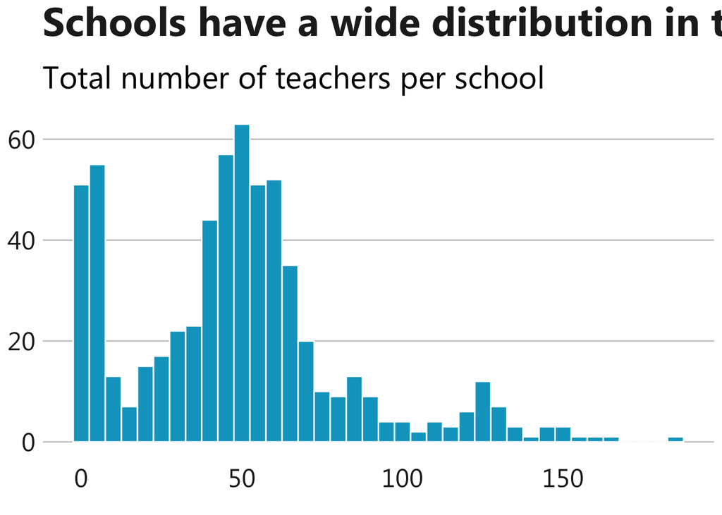

```r
# number of teachers per school
number_teachers_school <- county_data |>
  count(school_year, school_name)

ggplot(number_teachers_school, aes(n)) +
  geom_histogram(binwidth = 5, colour = "white", fill = "#00A4C7") +
  labs(title = "Schools have a wide distribution in the number of teachers",
       subtitle = "Total number of teachers per school") +
  tntp_style()
```

## Making denisty plots

The [`ggridges`](https://wilkelab.org/ggridges/) package contains additional plots for plotting distributions using ridgeline plots.

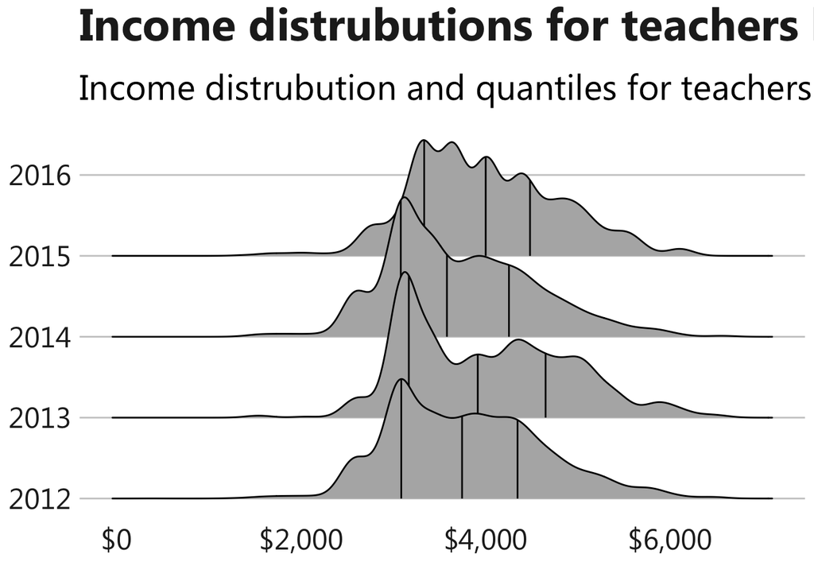

```r
ggplot(county_data, aes(x = t_salary, y = school_year, group = school_year)) +
  stat_density_ridges(quantile_lines = TRUE, quantiles = 4) +
  scale_x_continuous(labels = scales::dollar) +
  labs(title = "Income distrubutions for teachers has remained constant",
       subtitle = "Income distrubution and quantiles for teachers") +
  tntp_style()
```

## Working with survey data

```r
teacher_survey <- tntpr::teacher_pre_survey

# scales in HE questions, in order s tarting with the strongest
agree_disagree_scale <- rev(c("Strongly Agree", "Agree", "Somewhat Agree", "Somewhat Disagree", "Disagree", "Strongly Disagree"))

# put survey into long form and clean up question names
teacher_survey_he <- teacher_survey |>
  select(contains('state standards')) |>
  select(-starts_with("How would you")) |>
  pivot_longer(cols = everything(), names_to = 'question', values_to = 'response') |>
  mutate(question = str_extract(question, "\\[.*") |> str_remove_all("\\[|\\]"))

# calcualte percentage of responses to each high expectations question
teacher_survey_he_perc <- teacher_survey_he |>
  drop_na("response") |>
  # calculate the number of responses for each response option
  group_by(question, response) |>
  count(name = 'n_response') |>
  ungroup() |>
  # calculate the number of responses for each question
  group_by(question) |>
  mutate(n_question = sum(n_response)) |>
  ungroup() |>
  # calculate percentages
  mutate(
    # calculate percentages
    percent = n_response / n_question,
    # make a column that is text of the percent for plotting
    percent_pretty = scales::percent(percent, accuracy = 1)
  )

# calculate percentage of strongly agree and agree
teacher_survey_he_perc <- teacher_survey_he_perc |>
  mutate(scale_strength = ifelse(response %in% !!agree_disagree_scale[c(5,6)], 'Strong response', 'Weak response')) |>
  group_by(question, scale_strength) |>
  mutate(strong_response_percent = sum(percent)) |>
  ungroup() |>
  mutate(
    strong_response_percent = ifelse(response == 'Agree', strong_response_percent, NA),
    # create line breaks for questions ,which will make plots look better
    question = str_wrap(question, 50),
    response = factor(response, levels = agree_disagree_scale)
  )
```

### Plot likert items - highlights top two

[figure not shown]

```r
agree_scale_colors <- rev(c("#00A4C7", "#81D2EB", "#eeeeee", "#cccccc", "#aaaaaa", "#888888"))

# mapping of colors and responses for plot
agree_color_pal <- agree_scale_colors |>
  set_names(agree_disagree_scale)

ggplot(teacher_survey_he_perc, aes(percent, question, fill = response)) +
  geom_col() +
  geom_text(
    aes(label = scales::percent(strong_response_percent, accuracy = 1), x = strong_response_percent - .03),
    color = 'white', fontface='bold', size = 8
  ) +
  scale_x_continuous(labels = scales::percent, limits = c(0,1)) +
  scale_fill_manual(values = agree_color_pal, drop = FALSE) +
  guides(fill=guide_legend(nrow=2, byrow=TRUE, reverse = TRUE))  +
  labs(
    title = "High Expectations Survey Responses",
    x = NULL,
    y = NULL
  ) +
  tntp_style()
```

### Plot likert items - diverging

[figure not shown]

```r
div_scale_colors <- tntpr::colors_tntp_likert[-4]

# mapping of colors and responses for plot
div_color_pal <- div_scale_colors |>
  set_names(agree_disagree_scale)

legend_order <- c(agree_disagree_scale[c(1,2,3)], agree_disagree_scale[c(6,5,4)])

teacher_survey_div <- teacher_survey_he_perc |>
  mutate(
    perc_diverge = ifelse(str_detect(response, '[D|d]isagree'), percent * -1, percent),
    response = factor(response, levels = legend_order)
  )

ggplot(teacher_survey_div, aes(x = perc_diverge, y = question, fill = response)) +
  geom_col() +
  scale_fill_manual(
    values = div_color_pal, drop = FALSE,
    breaks = agree_disagree_scale,
    labels = agree_disagree_scale
  ) +
  geom_vline(aes(xintercept = 0), linetype = 1, linewidth = 1.2, alpha = .7) +
  scale_x_continuous(limits = c(-1, 1), breaks = seq(-1, 1, .25), labels = scales::percent) +
  labs(
    title = "High Expectations Survey Responses",
    x = NULL,
    y = NULL
  ) +
  tntp_style()
```